# Tugas4_MPDW

Raden Roro Jessica Faaris

2025-09-21

# PROSES MA(2)

## Bangkitkan model MA(2) dengan 𝜃1 = 0.4 dan 𝜃2 = 0.6 sebanyak 300 data (Manual dan dengan arima.sim)

```r
## Proses MA(2) dengan θ1 = 0.4, θ2 = 0.6

set.seed(1234)
n <- 300
theta1 <- 0.4
theta2 <- 0.6

# white noise
e <- rnorm(n+2)

# --- (a) Manual ---
ma2 <- rep(0, n)
for (i in 3:(n+2)) {
  ma2[i-2] <- e[i] + theta1*e[i-1] + theta2*e[i-2]
}
ma2
```

```
##   [1]  0.471173424 -1.745463687  0.141510314 -0.729712854 -0.114842790
##   [6] -0.472894305 -1.127948717 -1.443797742 -1.171879031 -1.723286222
##  [11] -1.461924092 -0.845074607  0.519525249  0.312187420  0.020572732
##  [16] -1.181770516 -1.508255550  1.534249256  0.598119283  1.012450498
##  [21] -0.556369299 -0.011041246 -0.774213194 -1.449939345 -0.420758391
##  [26] -1.662676381 -0.079747157 -1.556197355  0.718835126 -0.596243221
##  [31] -0.238298741 -1.070389923 -2.255260716 -2.120011486 -3.624543435
##  [36] -2.913580609 -2.138714925 -1.388210999  1.086560934 -0.768382742
##  [41] -0.413123964 -1.263954490 -1.619808057 -1.534624150 -2.091327966
##  [46] -2.276021753 -1.689013389 -1.457572736 -2.319068111 -1.602598402
##  [51] -2.425338748 -1.807763414 -1.233628102 -0.110845196  1.775654086
##  [56]  0.223607057  2.285258743 -0.979456751  1.157010823  2.116941328
##  [61]  1.378789117  0.845856907 -0.296314421  1.372262398 -0.432336811
##  [66]  1.978634754  1.193531021  1.688995021  0.939220832 -0.250827924
##  [71] -0.544575725  0.228395751  2.109671129  1.063681873 -0.209897795
```

[output cut: 45 more lines]

```r
# --- (b) Dengan arima.sim ---
ma2_sim <- arima.sim(list(order=c(0,0,2), ma=c(theta1, theta2)), n=n)
ma2_sim
```

```
## Time Series:
## Start = 1
## End = 300
## Frequency = 1
##   [1]  0.319892749 -0.033692645 -0.749809541  1.023224875 -0.103827746
##   [6]  1.553027734  1.508813504  1.490258435  0.638775303  0.057508568
##  [11] -0.761313741  1.006804154  0.046165301  2.226792228 -0.031351321
##  [16]  0.058227766 -0.452682262 -0.306828839 -0.408896770 -1.768664231
##  [21] -0.905163217 -1.653388217  0.814020129 -0.949587092  1.394975120
##  [26] -0.770061199  0.708742509  0.626264945  0.016220780  0.886163244
##  [31] -0.177443664 -0.837739266 -0.776948985  0.830630275  0.271737011
##  [36]  0.068438994 -0.509614613 -0.182137038  1.054967504  1.724174690
##  [41]  1.131301118  1.891160132 -0.238116411 -1.951472236 -1.868044756
##  [46] -2.111236903 -2.805388403 -0.673455997 -1.948408128 -0.202080988
##  [51] -2.147789666 -0.222949385  1.157974906  0.206928218  0.670946455
```

[output cut: 49 more lines]

## Buat plot time series, plot ACF, plot PACF dan plot EACF. Idenifikasi apakah data tersebut stasioner

### Plot time series

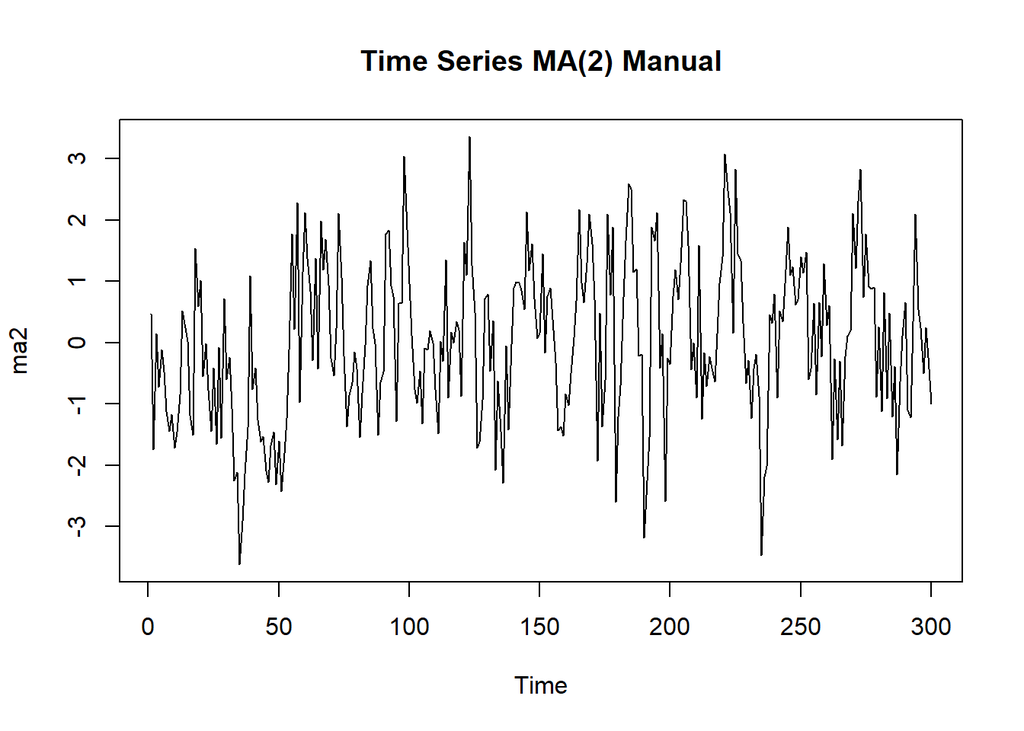

```r
ts.plot(ma2, main="Time Series MA(2) Manual")
```

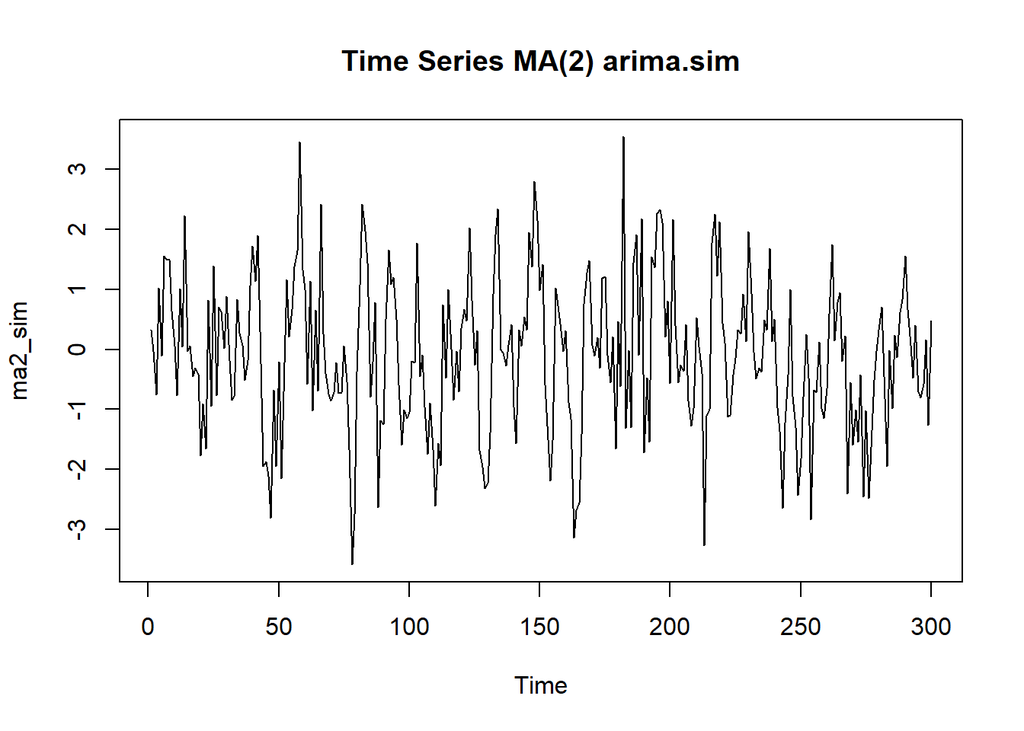

```r
ts.plot(ma2_sim, main="Time Series MA(2) arima.sim")
```

Berdasarkan plot time series, data hasil simulasi MA(2) terlihat berfluktuasi di sekitar rataan konstan tanpa tren. Hal ini menunjukkan bahwa data bersifat **stasioner dalam rataan**.

### Plot ACF

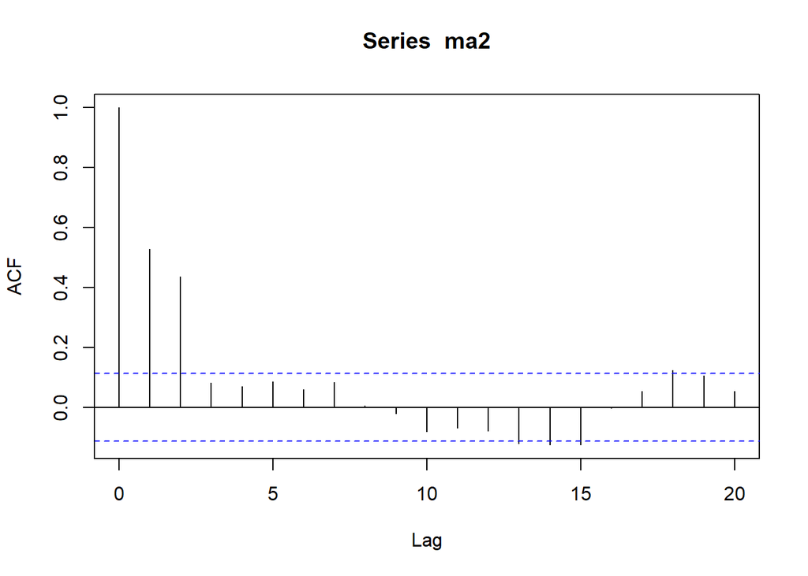

```r
acf(ma2, lag.max=20)
```

Plot ACF memperlihatkan **adanya autokorelasi signifikan** **hingga lag ke-2**, lalu **langsung *cut off***. Hal ini sesuai dengan teori bahwa proses MA(q) akan menghasilkan ACF yang *cut off* pada lag ke-q

### Plot PACF

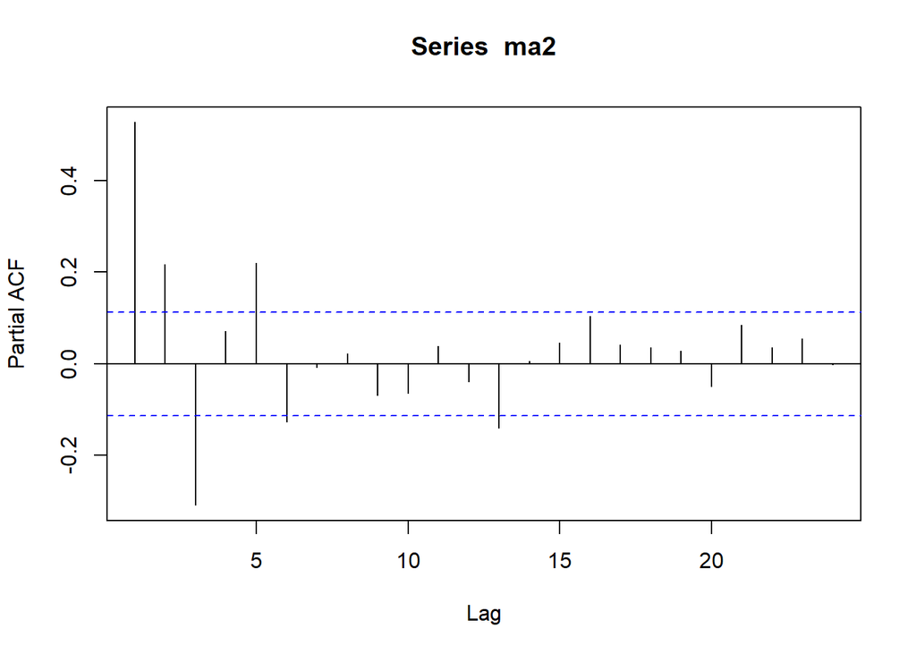

```r
pacf(ma2)
```

Plot PACF menunjukkan pola *tails off* (memudar secara bertahap), konsisten dengan sifat proses MA.

### Plot EACF

```r
TSA::eacf(ma2)
```

```
## AR/MA
##   0 1 2 3 4 5 6 7 8 9 10 11 12 13
## 0 x x o o o o o o o o o  o  x  x
## 1 x x x o o o o o o o o  o  o  o
## 2 x x x x o o o o o o o  o  o  o
## 3 x x x x o o o o o o o  o  o  o
## 4 x x x x o o o o o o o  o  o  o
## 5 x x o x x o x o o o o  o  o  o
## 6 o x o o x o o x o o o  o  o  o
## 7 x o x o x o o x o o o  o  o  o
```

Pola segitiga nol pada plot EACF muncul pada ordo AR(0) dan MA(2). Hal ini menunjukkan bahwa model yang tepat adalah **MA(2)**.

## Buat scatterplot antara 𝑌𝑡 dengan 𝑌𝑡−1, 𝑌𝑡 dengan 𝑌𝑡−2 serta 𝑌𝑡dengan 𝑌𝑡−3

### 𝑌𝑡 dengan 𝑌𝑡−1

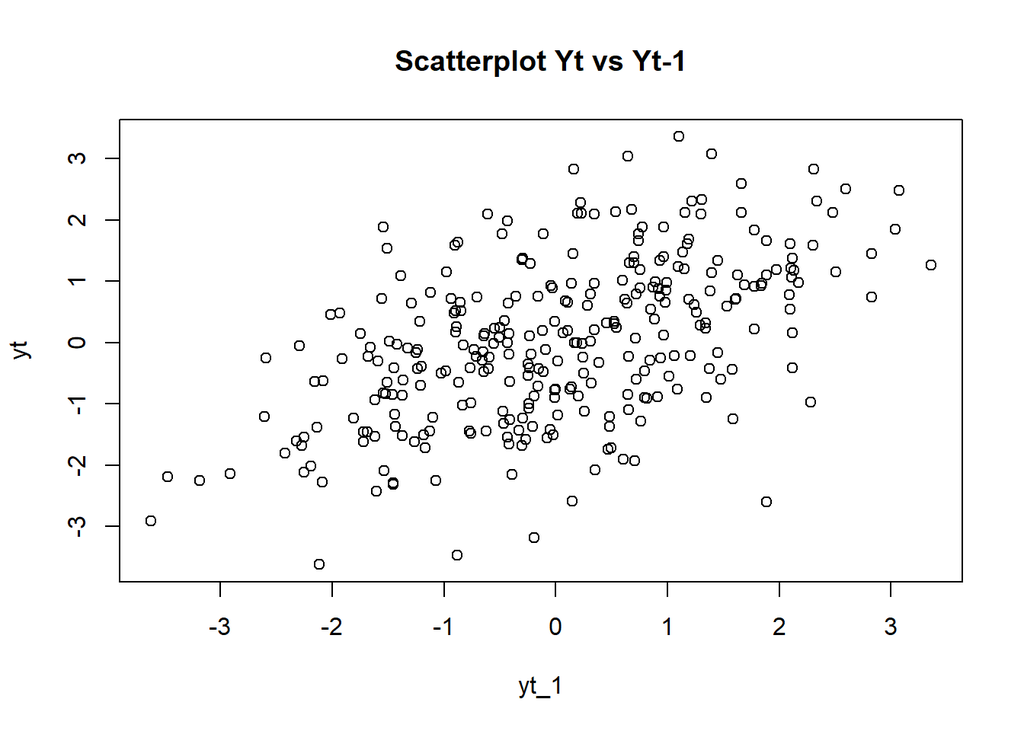

```r
yt   <- ma2[-1]
yt_1 <- ma2[-n]
plot(yt ~ yt_1, main="Scatterplot Yt vs Yt-1")
```

```r
cor(yt, yt_1)
```

```
## [1] 0.5285939
```

adanya hubungan positif.

### 𝑌𝑡 dengan 𝑌𝑡−2

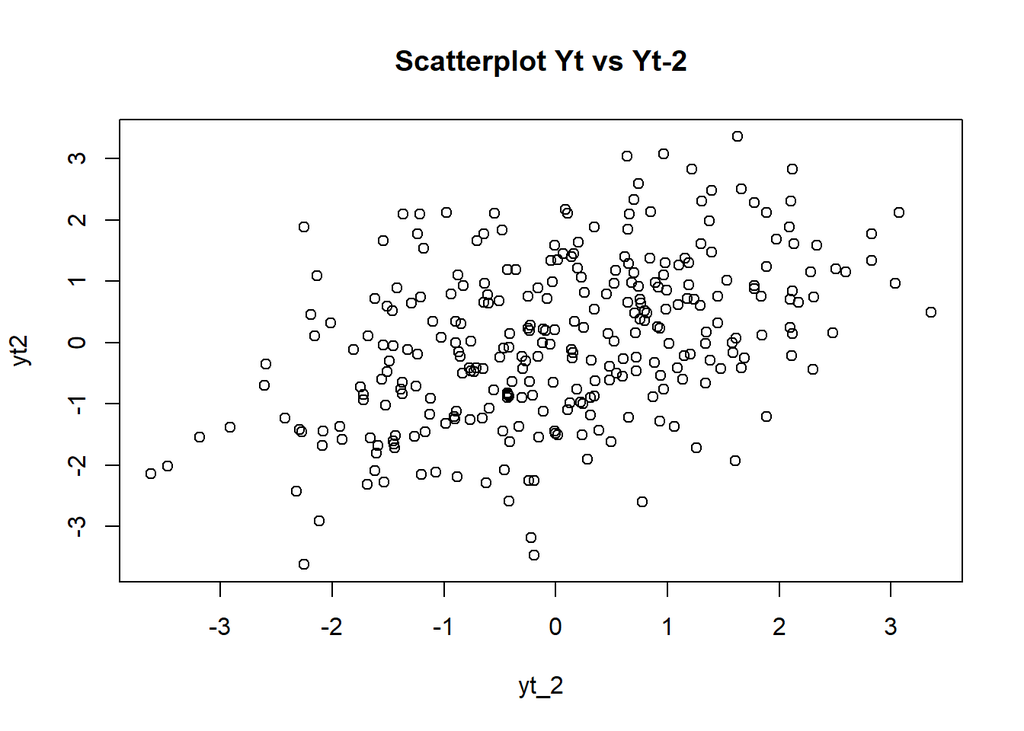

```r
yt2   <- ma2[-c(1,2)]
yt_2  <- ma2[-c((n-1), n)]
plot(yt2 ~ yt_2, main="Scatterplot Yt vs Yt-2")
```

```r
cor(yt2, yt_2)
```

```
## [1] 0.4372298
```

hubungan lebih lemah dibandingkan lag pertama.

### 𝑌𝑡 dengan 𝑌𝑡−3

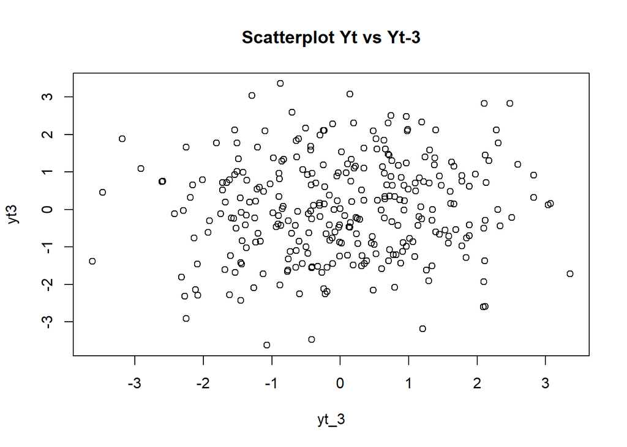

```r
yt3   <- ma2[-c(1,2,3)]
yt_3  <- ma2[-c((n-2), (n-1), n)]
plot(yt3 ~ yt_3, main="Scatterplot Yt vs Yt-3")
```

```r
cor(yt3, yt_3)
```

```
## [1] 0.08239345
```

hampir tidak memperlihatkan hubungan, sesuai dengan teori bahwa pengaruh MA berhenti setelah lag 2.

## Hitung autokorelasi masing masing baik dari data bangkitan maupun secara teoritis

### Secara teoritis

```r
denom <- 1 + theta1^2 + theta2^2
rho1 <- (theta1 + theta1*theta2)/denom
rho2 <- theta2/denom
rho_theory <- c(rho1, rho2, 0)
rho_theory
```

```
## [1] 0.4210526 0.3947368 0.0000000
```

### Dari data bangkitan

```r
acf(ma2, plot=FALSE)$acf[1:4]
```

```
## [1] 1.00000000 0.52794555 0.43532528 0.08203632
```

Autokorelasi simulasi pada lag 1 dan lag 2 mendekati nilai autokorelasi teoritis, sedangkan untuk lag di atas 2 nilainya mendekati nol. Ini konsisten dengan teori proses MA(2).

# PROSES AR(2)

## Bangkitkan model AR(2) dengan 𝜙1 = 0.5 dan 𝜙2 = 0.2 sebanyak 300 data (manual dan dengan arima.sim)

```r
## Proses AR(2) dengan φ1 = 0.5 dan φ2 = 0.2

set.seed(1234)
n <- 300
phi1 <- 0.5
phi2 <- 0.2

# white noise
wn <- rnorm(n)

# --- (a) Manual ---
ar2 <- numeric(n)
ar2[1] <- wn[1]   # nilai awal
ar2[2] <- wn[2] + phi1*ar2[1]   # nilai ke-2
for (i in 3:n) {
  ar2[i] <- wn[i] + phi1*ar2[i-1] + phi2*ar2[i-2]
}
ar2
```

```
##   [1] -1.207065749 -0.326103633  0.679976211 -2.070930324 -0.470345231
##   [6] -0.143302788 -0.740460400 -0.945522614 -1.185305386 -1.671795045
##  [11] -1.550151299 -2.107821103 -2.140194706 -1.427202757 -0.182146261
##  [16] -0.486799176 -0.790838346 -1.403974425 -1.697326562  1.286377013
##  [21]  0.437811414 -0.014504787 -0.360237983  0.276569492 -0.627483098
##  [26] -1.706632561 -0.404057179 -1.567010825 -0.879455148 -1.689078340
##  [31]  0.081867346 -0.772475074 -1.079304105 -1.195405128 -2.442656854
##  [36] -2.628028715 -3.982585377 -3.857891624 -3.019756746 -2.747354238
##  [41] -0.528132203 -1.882179673 -1.902080911 -1.608099392 -2.178805954
##  [46] -2.379537173 -2.732847970 -3.094317305 -2.617556366 -2.424491601
##  [51] -3.541788331 -2.837868410 -3.236181496 -3.200626439 -2.409859042
##  [56] -1.281998990  0.524846169 -0.767330137  1.327213794 -0.647667678
##  [61]  0.598197384  2.718556227  1.444157201  0.596156266  0.579304817
##  [66]  2.185968110  0.070237282  1.840139442  2.263681968  1.836341670
##  [71]  1.377800067  0.600699629  0.209385895  0.873119441  2.548707761
```

[output cut: 45 more lines]

```r
# --- (b) Dengan arima.sim ---
ar2_sim <- arima.sim(list(order=c(2,0,0), ar=c(phi1, phi2)), n=n)
ar2_sim
```

```
## Time Series:
## Start = 1
## End = 300
## Frequency = 1
##   [1] -1.51198789  0.14622636 -1.18196985  0.56474307 -0.60306545  0.10388597
##   [7]  0.83003262 -0.08294885  0.67897065  0.23492188 -0.88195786 -0.66407416
##  [13]  1.11136122  0.20873461 -0.49114292 -0.25784746  0.10298930  0.95524977
##  [19]  1.64218262  1.11266366  2.04934360  0.48294459 -1.69317239 -1.22168070
##  [25] -1.46533032 -3.29303745 -1.37711303 -2.13093915 -1.56694617 -2.79676390
##  [31] -1.16424698  0.74975075 -0.73605113 -0.33063433  1.63618567  1.68578230
##  [37]  3.08318771  1.87351626  1.40113562  0.56563940  1.99762053 -0.17390039
##  [43]  0.61988813  0.22884545  2.49024215  0.68285644 -0.66981152  0.03429730
##  [49] -0.15646235 -0.91049678 -0.35424977 -0.63474899 -1.06698309 -0.15960541
##  [55] -0.62486164 -2.17933215 -3.86637965 -2.94963843 -0.79390827 -0.14875244
##  [61]  0.98189570  1.44370281  1.23399457 -0.60132478  0.15170631  1.55281629
```

[output cut: 39 more lines]

## Buat plot time series, plot ACF, plot PACF dan plot EACF. Idenifikasi apakah data tersebut stasioner

### Plot time series

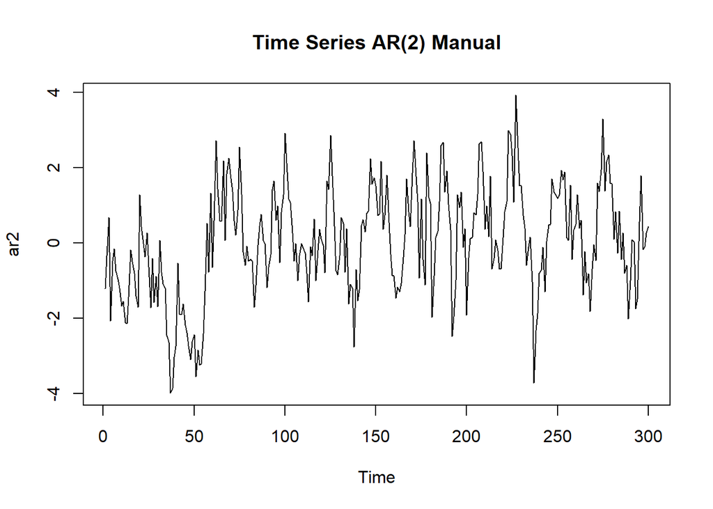

```r
ts.plot(ar2, main="Time Series AR(2) Manual")
```

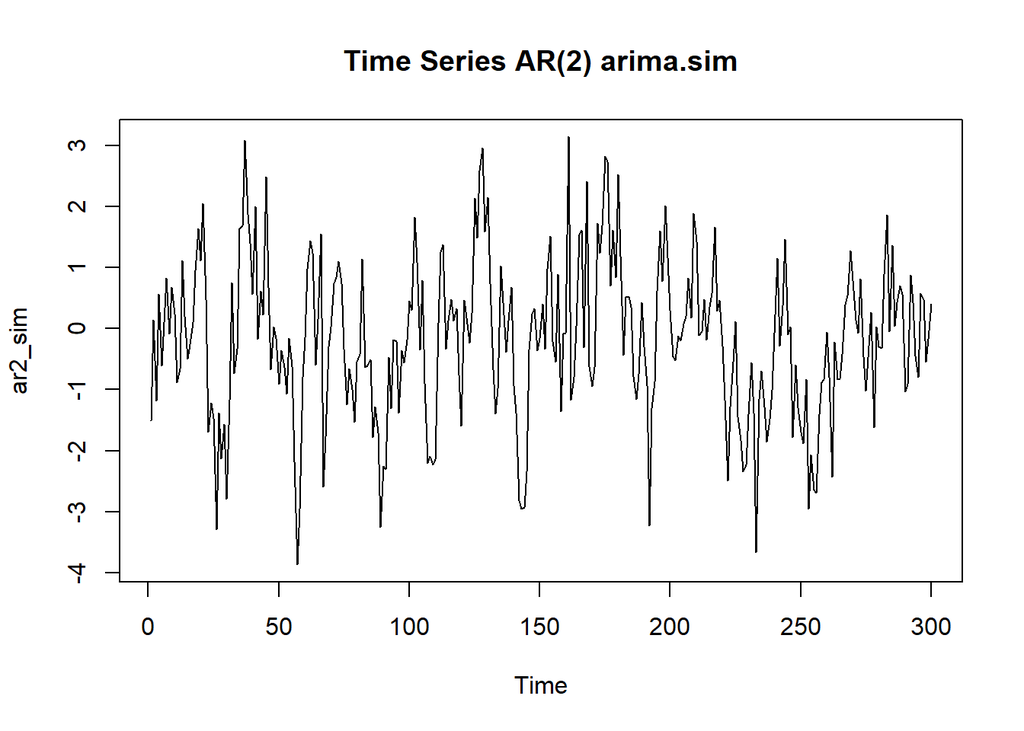

```r
ts.plot(ar2_sim, main="Time Series AR(2) arima.sim")
```

data hasil simulasi AR(2) berfluktuasi di sekitar rataan konstan. Tidak terdapat tren jangka panjang, sehingga data bersifat **stasioner**.

### Plot ACF

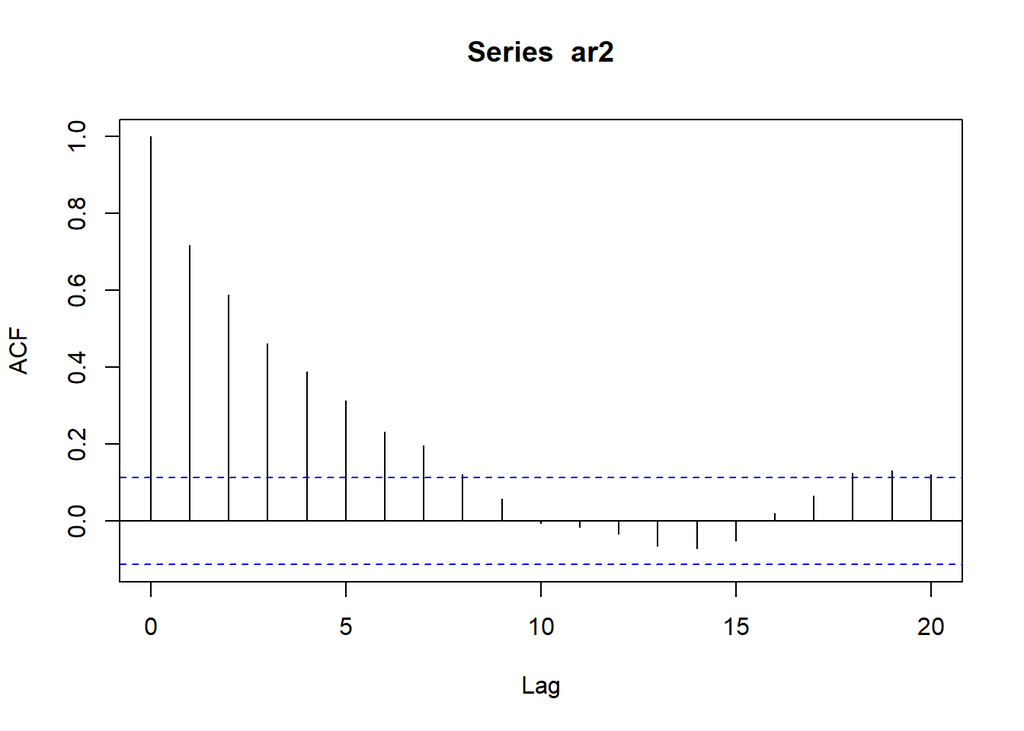

```r
acf(ar2, lag.max=20)
```

### Plot PACF

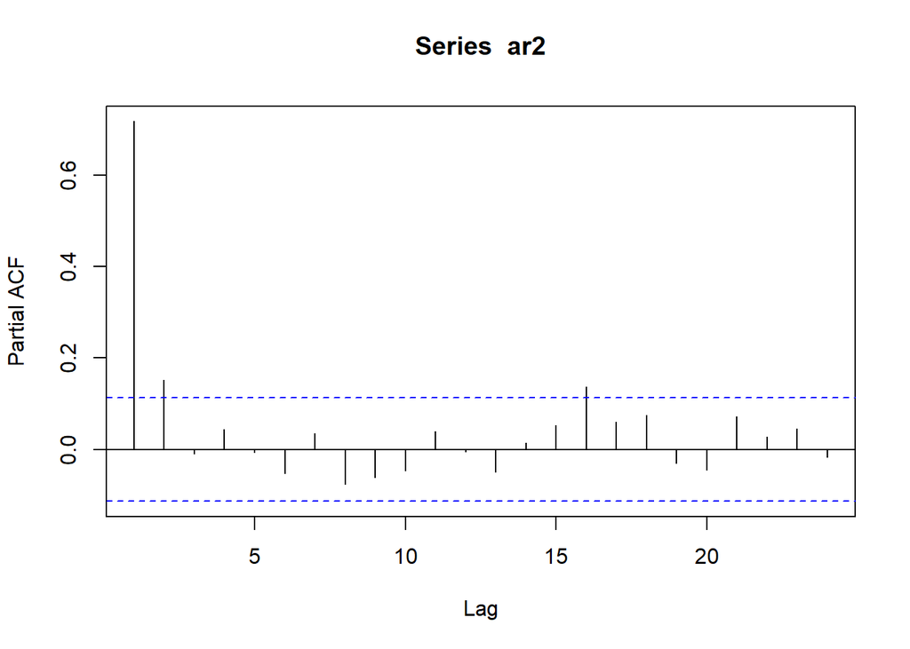

```r
pacf(ar2)
```

memperlihatkan *cut off* setelah lag ke-2. Hal ini sesuai teori bahwa PACF untuk AR(p) akan berhenti pada lag ke-p.

### Plot EACF

```r
TSA::eacf(ar2)
```

```
## AR/MA
##   0 1 2 3 4 5 6 7 8 9 10 11 12 13
## 0 x x x x x x x x o o o  o  o  o
## 1 x o o o o o o o o o o  o  o  o
## 2 o o o o o o o o o o o  o  o  o
## 3 x x o o o o o o o o o  o  o  o
## 4 x x o o o o o o o o o  o  o  o
## 5 o x o x o o x o o o o  o  o  o
## 6 x x x x o o o o o o o  o  o  o
## 7 x x x o x x o o o o o  o  o  o
```

Pola segitiga nol pada plot EACF muncul pada ordo AR(2) dan MA(0), sehingga mengindikasikan model **AR(2)**.

## Buat scatterplot antara 𝑌𝑡 dengan 𝑌𝑡−1, 𝑌𝑡 dengan 𝑌𝑡−2 serta 𝑌𝑡dengan 𝑌𝑡−3

### 𝑌𝑡 dengan 𝑌𝑡−1

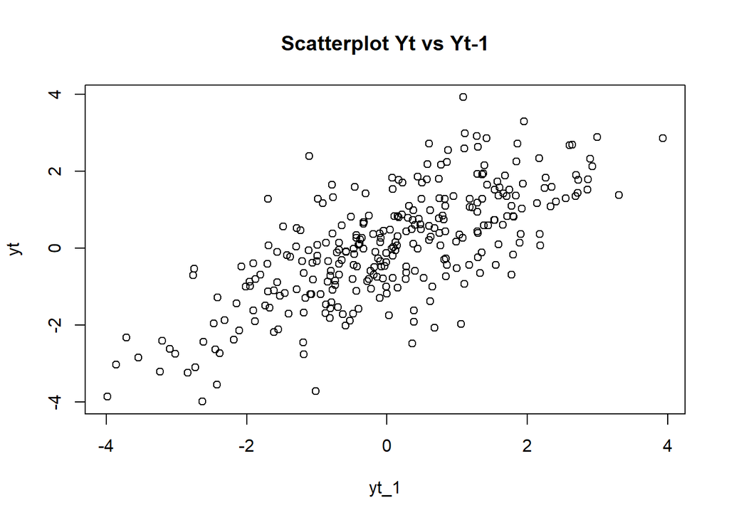

```r
yt   <- ar2[-1]
yt_1 <- ar2[-n]
plot(yt ~ yt_1, main="Scatterplot Yt vs Yt-1")
```

```r
cor(yt, yt_1)
```

```
## [1] 0.7181941
```

adanya hubungan positif kuat.

### 𝑌𝑡 dengan 𝑌𝑡−2

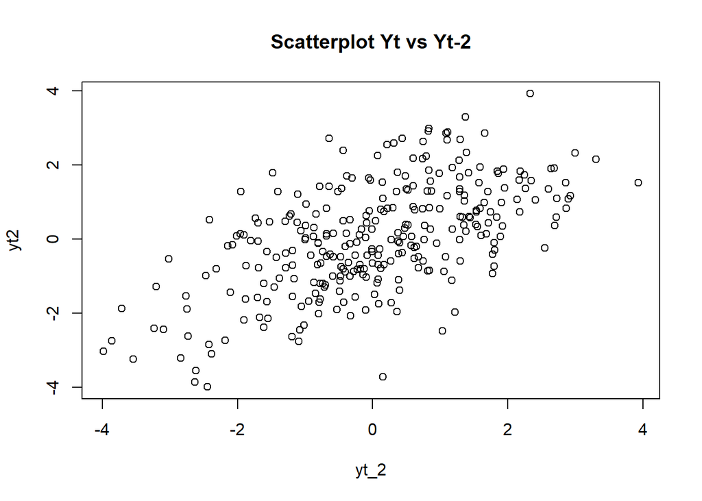

```r
yt2   <- ar2[-c(1,2)]
yt_2  <- ar2[-c((n-1), n)]
plot(yt2 ~ yt_2, main="Scatterplot Yt vs Yt-2")
```

```r
cor(yt2, yt_2)
```

```
## [1] 0.5889847
```

hubungan yang cukup jelas meskipun lebih lemah.

### 𝑌𝑡 dengan 𝑌𝑡−3

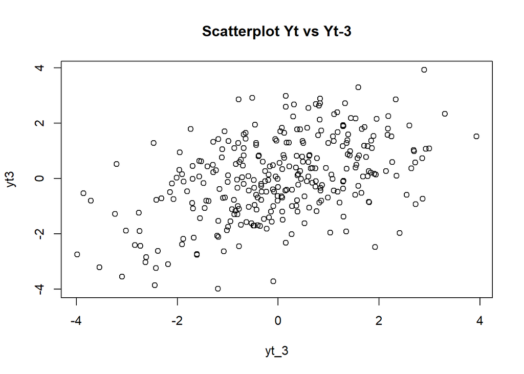

```r
yt3   <- ar2[-c(1,2,3)]
yt_3  <- ar2[-c((n-2), (n-1), n)]
plot(yt3 ~ yt_3, main="Scatterplot Yt vs Yt-3")
```

```r
cor(yt3, yt_3)
```

```
## [1] 0.4630342
```

menunjukkan hubungan yang lebih lemah lagi, namun masih ada pola.

## Hitung autokorelasi masing masing baik dari data bangkitan maupun secara teoritis

### Secara toritis

```r
# hitung autokorelasi teoritis
rho1 <- phi1 / (1 - phi2)
rho2 <- phi1*rho1 + phi2
rho3 <- phi1*rho2 + phi2*rho1
rho_theory <- c(rho1, rho2, rho3)
rho_theory
```

```
## [1] 0.62500 0.51250 0.38125
```

### Dari data bangkitan

```r
acf(ar2, plot=FALSE)$acf[1:4]
```

```
## [1] 1.0000000 0.7172065 0.5880802 0.4621694
```

Nilai autokorelasi hasil simulasi untuk lag 1–3 mendekati nilai teoritis berdasarkan persamaan Yule-Walker AR(2). Ini menunjukkan kesesuaian antara data simulasi dan teori.

# PROSES ARMA(2,2)

## Bangkitkan model ARMA(2,2) dengan 𝜃1 = 0.4, 𝜃2 = 0.6 ,𝜙1 = 0.5 dan 𝜙2 = 0.2 sebanyak 300 data (Manual dan arima.sim)

```r
## Proses ARMA(2,2) dengan φ1 = 0.5, φ2 = 0.2, θ1 = 0.4, θ2 = 0.6

set.seed(1234)
n <- 300
phi1 <- 0.5
phi2 <- 0.2
theta1 <- 0.4
theta2 <- 0.6

# white noise
wn <- rnorm(n+2)

# --- (a) Manual ---
arma22 <- numeric(n)
arma22[1] <- wn[1]
arma22[2] <- wn[2] + phi1*arma22[1] + theta1*wn[1]

for (i in 3:n) {
  arma22[i] <- wn[i] +
               phi1*arma22[i-1] + phi2*arma22[i-2] +
               theta1*wn[i-1]   + theta2*wn[i-2]
}
arma22
```

```
##   [1] -1.20706575 -0.80892993 -0.17470469 -1.99460202 -0.89073163 -1.57399907
##   [7] -1.07998865 -1.32768845 -2.00779067 -2.71323077 -2.93005255 -3.73095865
##  [13] -3.91341393 -3.54797330 -2.03714419 -1.41597933 -1.09484577 -2.01238927
##  [19] -2.73341934 -0.23493827 -0.06603372  0.93244599 -0.10335305  0.12377143
##  [25] -0.73299809 -1.79168410 -1.46320006 -2.75261323 -1.74869379 -2.98106689
##  [31] -1.12143708 -1.75317514 -1.33917373 -2.09061181 -3.56840137 -4.32233453
##  [37] -6.49939098 -7.02774300 -6.95246462 -6.26999191 -3.43892795 -3.74184510
##  [43] -2.97183210 -3.49823956 -3.96329426 -4.21591919 -4.99194641 -5.61517880
##  [49] -5.49499207 -5.32810453 -6.08211879 -5.70927870 -6.49640186 -6.19782008
##  [55] -5.63181852 -4.16631847 -1.43386885 -1.32659106  1.33518944 -0.57718024
##  [61]  1.13545859  2.56923457  2.89049812  2.80495288  1.68426164  2.77538380
##  [67]  1.29220742  3.17981522  3.04188011  3.84589812  3.47054592  2.25362466
##  [73]  1.27634579  1.31729358  3.02358707  2.83893413  1.81428668  0.10302896
##  [79] -0.45121970 -0.85290753 -0.66635425 -0.93510416 -2.14779642 -2.08562341
##  [85] -1.51503473 -0.24121274  0.91556687  0.64537308  0.48311177 -1.14217407
```

[output cut: 35 more lines]

```r
# --- (b) Dengan arima.sim ---
arma22_sim <- arima.sim(
  list(order=c(2,0,2), ar=c(phi1, phi2), ma=c(theta1, theta2)),
  n=n
)
arma22_sim
```

```
## Time Series:
## Start = 1
## End = 300
## Frequency = 1
##   [1] -1.0855331992  0.2021284195  0.5102225152  0.3117577215  1.1440866081
##   [6]  0.4569511840 -0.3804463528 -0.8757819251  0.3166500424  0.2549056469
##  [11]  0.2592218260 -0.3290225711 -0.2948039579  0.8417610110  2.0860944035
##  [16]  2.3427005222  3.4797292735  1.9702883307 -0.2703822164 -1.6091781981
##  [21] -2.9699024449 -4.6121752647 -3.5735241187 -4.6576052398 -3.2455884314
##  [26] -4.7021049295 -3.2231195360 -1.3940058484 -1.1346986135 -0.1752040212
##  [31]  1.0623015011  2.1418761579  4.7392121727  4.1182608280  4.0004548295
##  [36]  2.2502034688  3.0645577115  0.9645315043  1.7489003188  0.3724604937
##  [41]  2.9537132266  1.8162605835  1.0974763558  0.1760865590 -0.5446303395
##  [46] -0.9525033422 -0.8123258954 -1.3227469680 -1.5334325501 -0.9672480414
##  [51] -1.3288936548 -2.5250400522 -5.1130294929 -5.8037895788 -4.2935914350
```

[output cut: 49 more lines]

## Buat plot time series, plot ACF, plot PACF dan plot EACF. Idenifikasi apakah data tersebut stasioner

### Plot time series

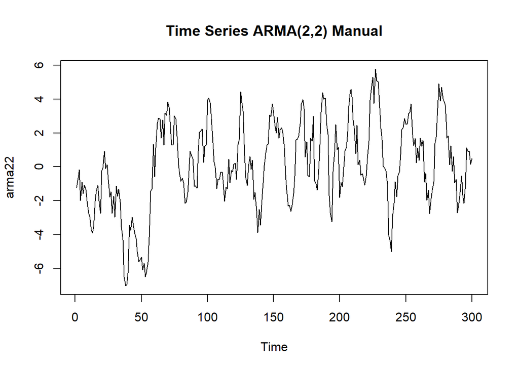

```r
ts.plot(arma22, main="Time Series ARMA(2,2) Manual")
```

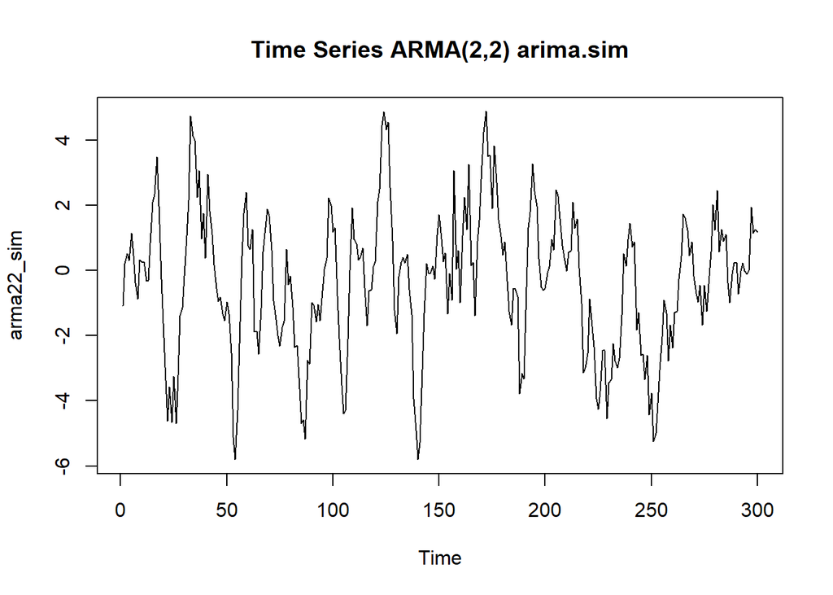

```r
ts.plot(arma22_sim, main="Time Series ARMA(2,2) arima.sim")
```

terlihat bahwa data hasil simulasi ARMA(2,2) berfluktuasi di sekitar rataan konstan tanpa adanya tren. Hal ini menunjukkan bahwa data yang dibangkitkan bersifat **stasioner dalam rataan**.

### Plot ACF

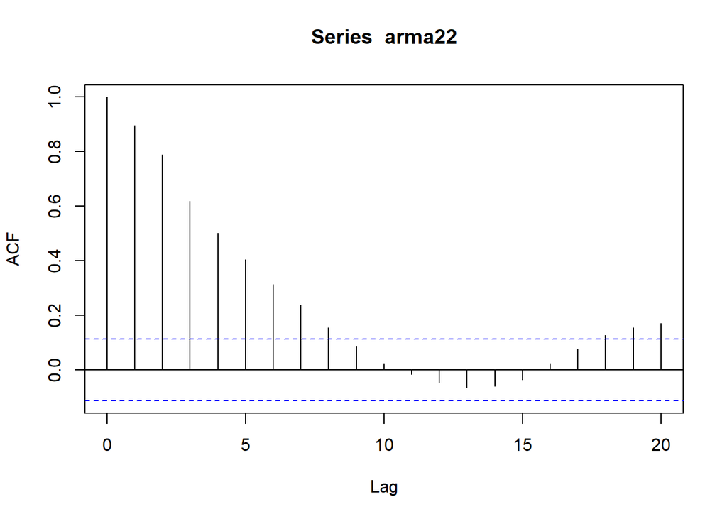

```r
acf(arma22, lag.max=20)
```

### Plot PACF

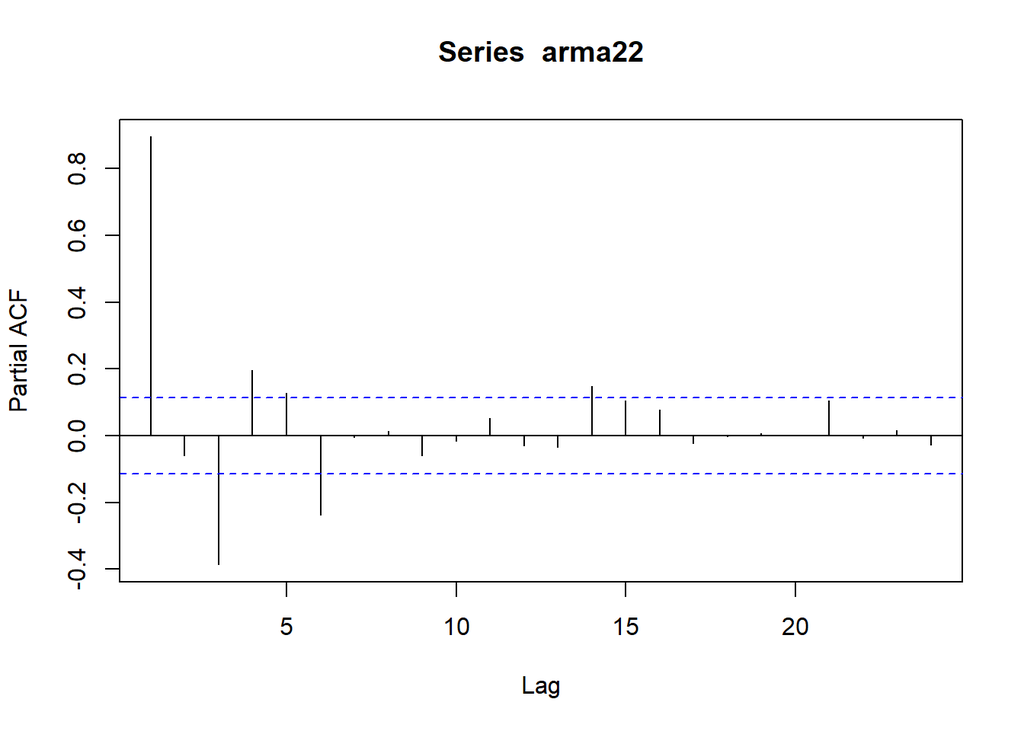

```r
pacf(arma22)
```

Plot PACF juga menunjukkan **adanya autokorelasi pada beberapa lag awal, kemudian memudar.** Pola ini konsisten dengan teori ARMA, di mana PACF tidak langsung *cut off* seperti AR murni, melainkan juga *tails off*.

### Plot EACF

```r
TSA::eacf(arma22)
```

```
## AR/MA
##   0 1 2 3 4 5 6 7 8 9 10 11 12 13
## 0 x x x x x x x x o o o  o  o  o
## 1 o x o o o o x o o o o  o  o  o
## 2 x x o o o o x o o o o  o  o  o
## 3 x x o x o o x o o o o  o  o  o
## 4 x x x x o o x o o o o  o  o  o
## 5 x x x x x x x o o o o  o  o  o
## 6 o o x o x x o o o o o  o  o  o
## 7 o o x o x x o x o o o  o  o  o
```

terlihat adanya pola segitiga nol pada ordo AR(2) dan ordo MA(2). Hal ini mengindikasikan bahwa model yang sesuai adalah **ARMA(2,2)**, sesuai dengan parameter pembangkitan.

## Buat scatterplot antara 𝑌𝑡 dengan 𝑌𝑡−1, 𝑌𝑡 dengan 𝑌𝑡−2 serta 𝑌𝑡dengan 𝑌𝑡−3

### 𝑌𝑡 dengan 𝑌𝑡−1

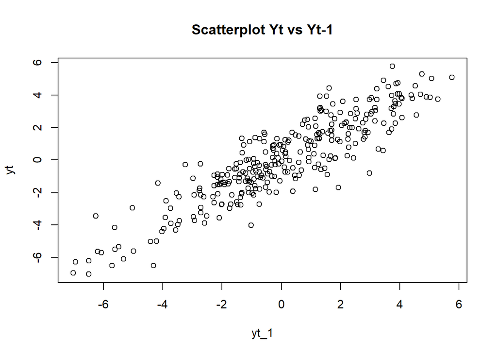

```r
yt   <- arma22[-1]
yt_1 <- arma22[-n]
plot(yt ~ yt_1, main="Scatterplot Yt vs Yt-1")
```

```r
cor(yt, yt_1)
```

```
## [1] 0.8955216
```

adanya hubungan positif antar lag pertama.

### 𝑌𝑡 dengan 𝑌𝑡−2

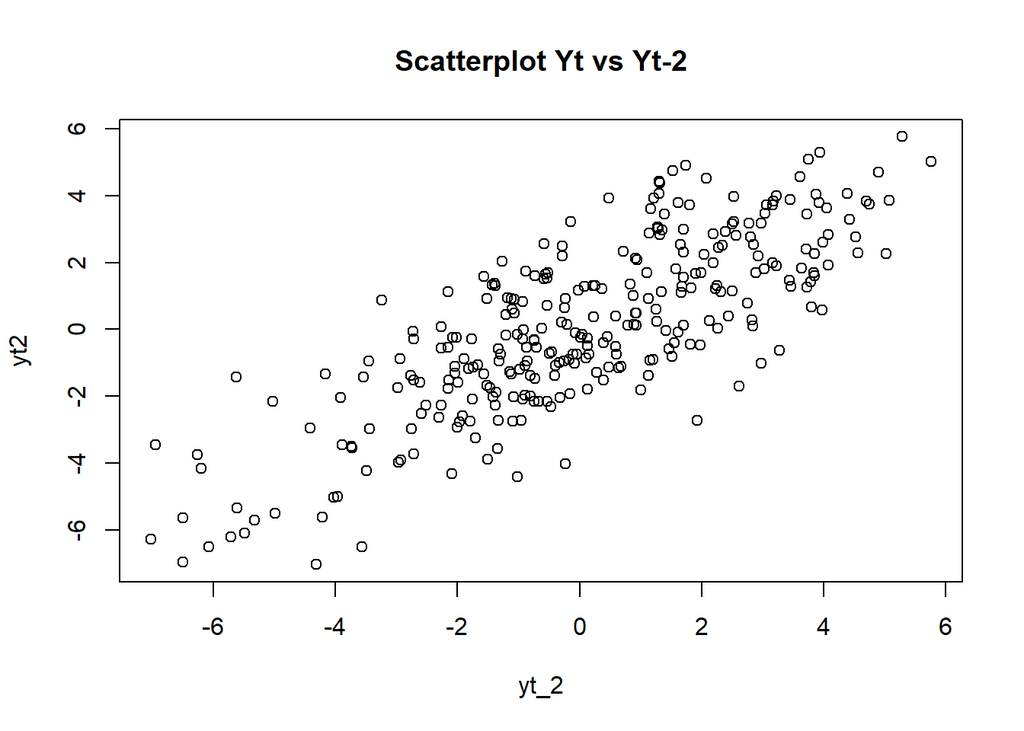

```r
yt2   <- arma22[-c(1,2)]
yt_2  <- arma22[-c((n-1), n)]
plot(yt2 ~ yt_2, main="Scatterplot Yt vs Yt-2")
```

```r
cor(yt2, yt_2)
```

```
## [1] 0.7899614
```

adanya hubungan yang lebih lemah dibandingkan lag pertama, namun masih terlihat adanya pola hubungan

### 𝑌𝑡 dengan 𝑌𝑡−3

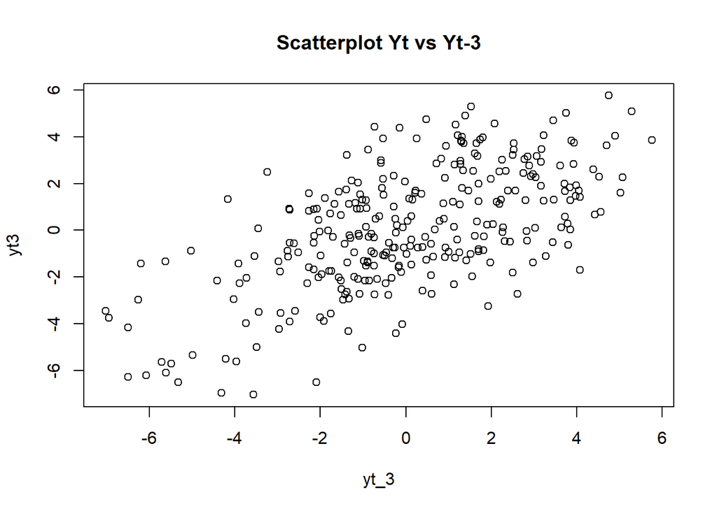

```r
yt3   <- arma22[-c(1,2,3)]
yt_3  <- arma22[-c((n-2), (n-1), n)]
plot(yt3 ~ yt_3, main="Scatterplot Yt vs Yt-3")
```

```r
cor(yt3, yt_3)
```

```
## [1] 0.6195458
```

Hal ini konsisten dengan **sifat ARMA** di mana **pengaruh lag semakin berkurang seiring bertambahnya jarak.**

## Hitung autokorelasi masing masing baik dari data bangkitan maupun secara teoritis

### Secara teoritis

```r
# Autokorelasi teoritis
acf_theory <- ARMAacf(ar=c(phi1, phi2), ma=c(theta1, theta2), lag.max=10)
acf_theory[2:4]   # rho1, rho2, rho3
```

```
##         1         2         3
## 0.8591993 0.7491908 0.5464353
```

### Dari data bangkitan

```r
acf(arma22, plot=FALSE)$acf[1:4]
```

```
## [1] 1.0000000 0.8951048 0.7894326 0.6190027
```

Nilai autokorelasi hasil simulasi mendekati nilai autokorelasi teoritis yang dihitung dengan fungsi `ARMAacf`. Hal ini membuktikan bahwa data bangkitan sesuai dengan model ARMA(2,2) dengan parameter yang digunakan.